# Reproducible Research: Peer Assessment 1

## Loading and preprocessing the data

### Reading the data

I load the dataset in memory as an R object called “data”

```r
unzip(zipfile = "activity.zip")
data <- read.csv("activity.csv", header = TRUE, sep = ",")
head(data)
```

```
##   steps       date interval
## 1    NA 2012-10-01        0
## 2    NA 2012-10-01        5
## 3    NA 2012-10-01       10
## 4    NA 2012-10-01       15
## 5    NA 2012-10-01       20
## 6    NA 2012-10-01       25
```

### Transform/adapt the dataset with appropriate variables to be able to answer the questions.

**Converting the variables to appropriate class**  
1. I create a new column/variable called “newdate”“, which will be the conversion of the variable”date" from factor to date class. I keep the original factor variable, as I will use it to compute the daily sum of steps later on.  
2. I convert the variable “steps”" from int class to numeric class.  
3. I convert the variable “interval”" from int class to numeric class.  
4. I create a new variable called “weekday”" to identify weekdays in the dataframe.

```r
data$newdate <- as.Date(data$date, format = "%Y-%m-%d")
data$steps <- as.numeric(data$steps)
data$interval <- as.numeric(data$interval)
data$weekday <- weekdays(data$newdate, abbreviate = TRUE)
```

**Categorize the days as belonging to weekday category or weekend category**  
1. I create a temporary data frame which will serve as a corresponding matrix for the categorization of the days (weekday/weekend).  
2. I create a new column/variable called “daycat”" in which I will insert the corresponding category, matching the one in the “templabel” dataframe.  
3. I check that all my new variables are in the dataframe.

```r
templabel <- data.frame(c("Lun", "Mar", "Mer", "Jeu", "Ven", "Sam", "Dim"), c("weekday", "weekday", "weekday", "weekday", "weekday", "weekend", "weekend"))
colnames(templabel) <- c("weekday", "category")
data$daycat = templabel$category[match(data$weekday, templabel$weekday)]
head(data)
```

```
##   steps       date interval    newdate weekday  daycat
## 1    NA 2012-10-01        0 2012-10-01     Lun weekday
## 2    NA 2012-10-01        5 2012-10-01     Lun weekday
## 3    NA 2012-10-01       10 2012-10-01     Lun weekday
## 4    NA 2012-10-01       15 2012-10-01     Lun weekday
## 5    NA 2012-10-01       20 2012-10-01     Lun weekday
## 6    NA 2012-10-01       25 2012-10-01     Lun weekday
```

## What is mean total number of steps taken per day?

**Total number of steps taken per day**

```r
dataStepsSum <- aggregate(steps ~ date, data, sum)
dataStepsSum
```

```
##          date steps
## 1  2012-10-02   126
## 2  2012-10-03 11352
## 3  2012-10-04 12116
## 4  2012-10-05 13294
## 5  2012-10-06 15420
## 6  2012-10-07 11015
## 7  2012-10-09 12811
## 8  2012-10-10  9900
## 9  2012-10-11 10304
## 10 2012-10-12 17382
## 11 2012-10-13 12426
## 12 2012-10-14 15098
## 13 2012-10-15 10139
## 14 2012-10-16 15084
```

[output cut: 39 more lines]

**Histogram figure of the total number of steps each day**

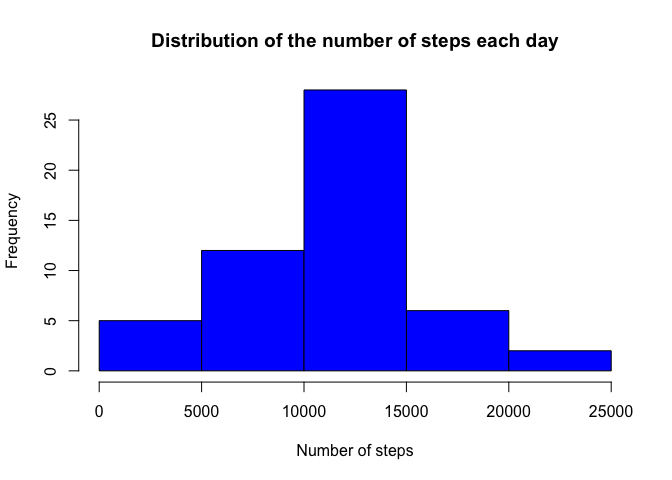

```r
hist(dataStepsSum$steps, col = "blue", main = "Distribution of the number of steps each day", xlab = "Number of steps", ylab = "Frequency")
```

**Mean and median of the total number of steps**

```r
meansteps <- mean(dataStepsSum$steps)
mediansteps <- median(dataStepsSum$steps)
```

Mean of the total number of steps is :

```
## [1] 10766.19
```

Median of the total number of steps is :

```
## [1] 10765
```

## What is the average daily activity pattern?

**Time series plot of the 5-minute interval**

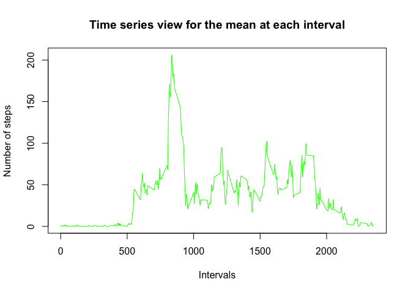

```r
dataInterval <- aggregate(steps ~ interval, data, mean)
plot(dataInterval$interval, dataInterval$steps, type = "l", col = "green", main = "Time series view for the mean at each interval", xlab = "Intervals", ylab = "Number of steps")
```

**Maximum number of steps**

```r
max_interval <- dataInterval[which.max(dataInterval$steps),1]
```

The maximum number of steps occurs at the 5-minute interval :

```
## [1] 835
```

## Imputing missing values

**Total number of missing values in the dataframe**

```r
sumMiss <- sum(is.na(data))
```

The number of missing value in the dataframe is :

```
## [1] 2304
```

**Imputing missing value : create a new dataset**  
I reorder the columns order of my dataset : placing the “date” column in first position and the “steps” column in second position.

```r
data2 <- data[, c(2, 1, 3, 4, 5, 6)]
```

```r
dataSteps1 <- aggregate(steps ~ weekday, data, mean)
data2temp <- data2[rowSums(is.na(data2)) > 0,]
data2temp$steps = dataSteps1$steps[match(data2temp$weekday, dataSteps1$weekday)]
data3temp <- data2[complete.cases(data2), ]
finaldata <- rbind(data3temp, data2temp)
head(finaldata)
```

```
##           date steps interval    newdate weekday  daycat
## 289 2012-10-02     0        0 2012-10-02     Mar weekday
## 290 2012-10-02     0        5 2012-10-02     Mar weekday
## 291 2012-10-02     0       10 2012-10-02     Mar weekday
## 292 2012-10-02     0       15 2012-10-02     Mar weekday
## 293 2012-10-02     0       20 2012-10-02     Mar weekday
## 294 2012-10-02     0       25 2012-10-02     Mar weekday
```

## What is mean total number of steps taken per day?

**Total number of steps taken per day**

```r
dataStepsSum2 <- aggregate(steps ~ date, finaldata, sum)
dataStepsSum2
```

```
##          date     steps
## 1  2012-10-01  9974.857
## 2  2012-10-02   126.000
## 3  2012-10-03 11352.000
## 4  2012-10-04 12116.000
## 5  2012-10-05 13294.000
## 6  2012-10-06 15420.000
## 7  2012-10-07 11015.000
## 8  2012-10-08  9974.857
## 9  2012-10-09 12811.000
## 10 2012-10-10  9900.000
## 11 2012-10-11 10304.000
## 12 2012-10-12 17382.000
## 13 2012-10-13 12426.000
## 14 2012-10-14 15098.000
```

[output cut: 47 more lines]

**Histogram figure of the total number of steps each day**

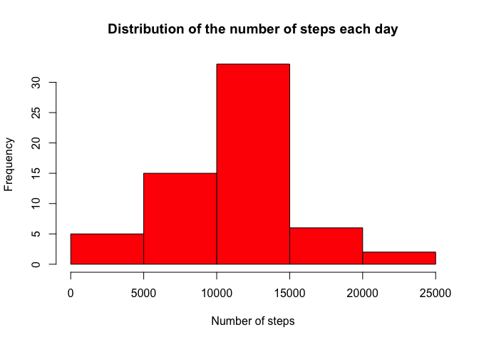

```r
hist(dataStepsSum2$steps, col = "red", main = "Distribution of the number of steps each day", xlab = "Number of steps", ylab = "Frequency")
```

**Check the difference between values from orginal dataframe and missing values filled in dataframe :**

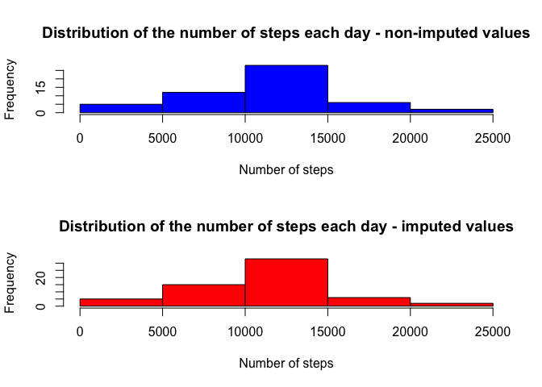

```r
par(mfrow = c(2,1))
hist(dataStepsSum$steps, col = "blue", main = "Distribution of the number of steps each day - non-imputed values", xlab = "Number of steps", ylab = "Frequency")
hist(dataStepsSum2$steps, col = "red", main = "Distribution of the number of steps each day - imputed values", xlab = "Number of steps", ylab = "Frequency")
```

Comparing the two graphs, we can see that the global pattern is the same.

**Mean and median of the total number of steps**

```r
meansteps2 <- mean(dataStepsSum2$steps)
mediansteps2 <- median(dataStepsSum2$steps)
```

Mean of the total number of steps is :

```
## [1] 10821.21
```

Median of the total number of steps is :

```
## [1] 11015
```

**Difference between non imputed values and imputed values**

```r
mean_gap <- meansteps2 - meansteps
median_gap <- mediansteps2 - mediansteps
sum_gap <- sum(dataStepsSum2$steps) - sum(dataStepsSum$steps)
```

The difference mean between imputed data and non-imputed data is :

```
## [1] 55.02092
```

The difference median between imputed data and non-imputed data is :

```
## [1] 250
```

The difference sum between imputed data and non-imputed data is :

```
## [1] 89485.79
```

## Are there differences in activity patterns between weekdays and weekends?

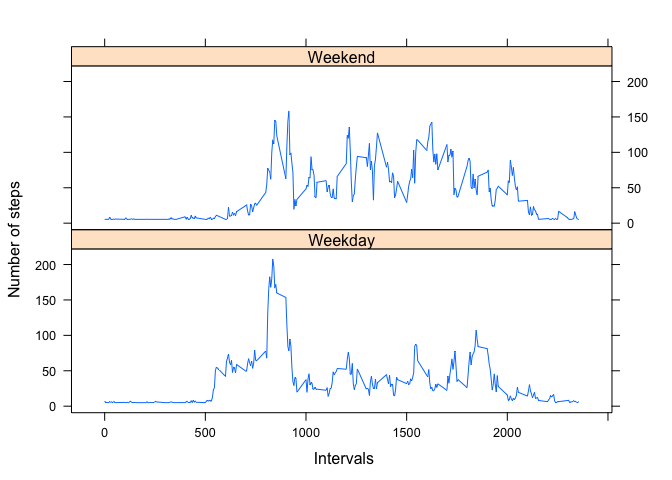

```r
library(lattice)
datatempX <- finaldata[, c(2, 3, 5, 6)]
zWeekday <- subset(datatempX, datatempX$daycat=="weekday")
zWeekend <- subset(datatempX, datatempX$daycat=="weekend")
zWeekdaymean <- aggregate(steps ~ interval, zWeekday, mean)
zWeekendmean <- aggregate(steps ~ interval, zWeekend, mean)
zWeekdaymean$daycat = "Weekday"
zWeekendmean$daycat = "Weekend"
zAlldays <- rbind(zWeekdaymean, zWeekendmean)
xyplot(steps ~ interval | daycat, layout = c(1,2), data = zAlldays, type = "l", xlab = " Intervals", ylab = "Number of steps" )
```